# K-Nearest Neighbors Classifier

The *k-nearest neighbors algorithm*, also known as *KNN* or *k-NN*, is a **non-parametric**, **supervised** learning classifier, which uses proximity to make classifications or predictions about the grouping of an individual data point.

For classification problems, a class label is assigned on the basis of a majority vote, i.e. the label that is most frequently represented around a given data point is used.

For regression problems use a similar concept as classification problem, but in this case, the average the k nearest neighbors is taken to make a prediction.

## Intuition

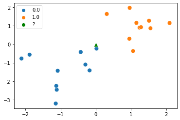

```python
ax.figure
```

## Determining Distances

In order to determine which data points are closest to a given query point, the distance between the query point and the other data points will need to be calculated.

While there are several distance measures that you can choose from, we will only cover some of them.

### Minkowski Distance

This distance measure is the generalized form of Euclidean and Manhattan distance metrics. The parameter, $p$, in the formula below, allows for the creation of other distance metrics

$$ \left( \sum_{i=1}^n | x_i - y_i | \right)^{\frac{1}{p}} $$

### Hamming Distance

This technique is used typically used with Boolean or string vectors, identifying the points where the vectors do not match. As a result, it has also been referred to as the overlap metric.

$$ \sum_{i=1}^n [\![ x_i = y_i ]\!] $$

### Cosine Distance

This distance metric is used mainly to calculate similarity between two vectors. It is measured by the cosine of the angle between two vectors and determines whether two vectors are pointing in the same direction. It is often used to measure document similarity in text analysis.

$$ \frac{1}{||\boldsymbol{x}|| || \boldsymbol{y} ||} \sum_{i=1}^n x_i \cdot y_i $$

## Defining K

The $K$ value in the KNN algorithm defines how many neighbors will be checked to determine the classification of a specific query point. For example, if $K=1$, the instance will be assigned to the same class as its single nearest neighbor. Defining $K$ can be a balancing act as different values can lead to overfitting or underfitting.

Lower values of $K$ can have high variance, but low bias, and larger values of $K$ may lead to high bias and lower variance.

The choice of $K$ will largely depend on the input data as data with more outliers or noise will likely perform better with higher values of $K$. Ideally, the value of $K$ should prevent ties in classification. You can use model selection and validation techniques to determine the optimal value of $K$ for your dataset.

**Excercise**

To apply model selection and validation techniques the KNN algorithm we train a KNN model and validating the results for multiple trials of $K$. The estimated out-of-sample error ($E_{out}$) is then plotted against the corresponding values of $K$ tested for each model.

Typically the plot will have a shape like this

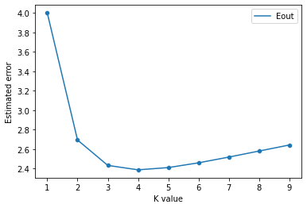

```python
ax.figure
```

- How do you choose the best $K$ based on the plot and why?
- What happens if you choose a lower or a higher $K$?
- Despite this method apply to many other models, why it could be difficult?

**Excercise**

Based on the intuition of how the KNN classifier works, write the algorithm using the next notation

Input:

- The dataset $\mathcal{D}=\{(\boldsymbol{x}_1, y_1), \cdots, (\boldsymbol{x}_N, y_N)\}$.
- A distance function $d(\cdot, \cdot)$.
- A point to classify $\boldsymbol{z}$

It's also worth noting that the KNN algorithm is also part of a family of *lazy learning* models, meaning that it only stores a training dataset versus undergoing a training stage.

This also means that all the computation occurs when a classification or prediction is being made. Since it heavily relies on memory to store all its training data, it is also referred to as an instance-based or memory-based learning method.

What is the problem with this?